# AE 07: Multiple Linear Regression

Credit Cards

**Important**

- Open [RStudio](https://rstudio.collegeofidaho.edu/) and create a subfolder in your AE folder called “AE-07”.
- Go to the [Canvas](https://cofi.instructure.com/courses/17093/assignments/202838) and locate your `AE-07` assignment to get started.
- Upload the `ae-07.qmd` file into the folder you just created.

## Packages + data

```r
library(readr)
library(tidyverse)
library(ggformula)
library(broom)
library(mosaic)
library(knitr)
library(ISLR2)
library(GGally)
library(yardstick)
```

The data for this AE is from the `Credit` data set in the **ISLR2** R package. It is a simulated data set of 400 credit card customers. We will focus on the following variables:

**Response**

- `Limit`: Credit limit

**Predictors**

- Everyone:
  - `Rating`: Credit Rating
- Group 1:
  - `Age`
  - `Own`
- Group 2:
  - `Balance`
  - `Student`
- Group 3:
  - `Education`
  - `Region`
- Group 4:
  - `Income`
  - `Married`

## Analysis goal

The goals of this analysis is to fit a multiple linear regression model that that predicts a person’s credit limit.

## Exercise 0

Look at the documentation for the data using `?Credit` and Google to figure out what each of your variables represents. What is a credit rating and what is a credit limit as it applies to a credit card? The primary credit rating in the US is called a FICO score. Use `favstats` on `Rating`. Do you think that `Rating` corresponds to the borrower’s FICO score?

```r
favstats(~Rating, data = Credit)
```

```
 min     Q1 median     Q3 max   mean       sd   n missing
  93 247.25    344 437.25 982 354.94 154.7241 400       0
```

Without writing any more code (i.e. just using what you know about the world):

- Do you think `Rating` will be a good predictor of `Limit`?

  Yes, it is.
- In addition to `Limit`, everyone has been assigned two additional variables, one quantitative and one categorical. Do you think these two variables will be predictive of `Limit`?

## Exercise 1

Use the function `ggpairs` from the `GGally` package (already loaded) to create a matrix of plots and correlations for your four variables of interest. Note that you will have to use `select` to select the four columns you are interested in. Which variable do you think will be the best predictor of `Limit`?

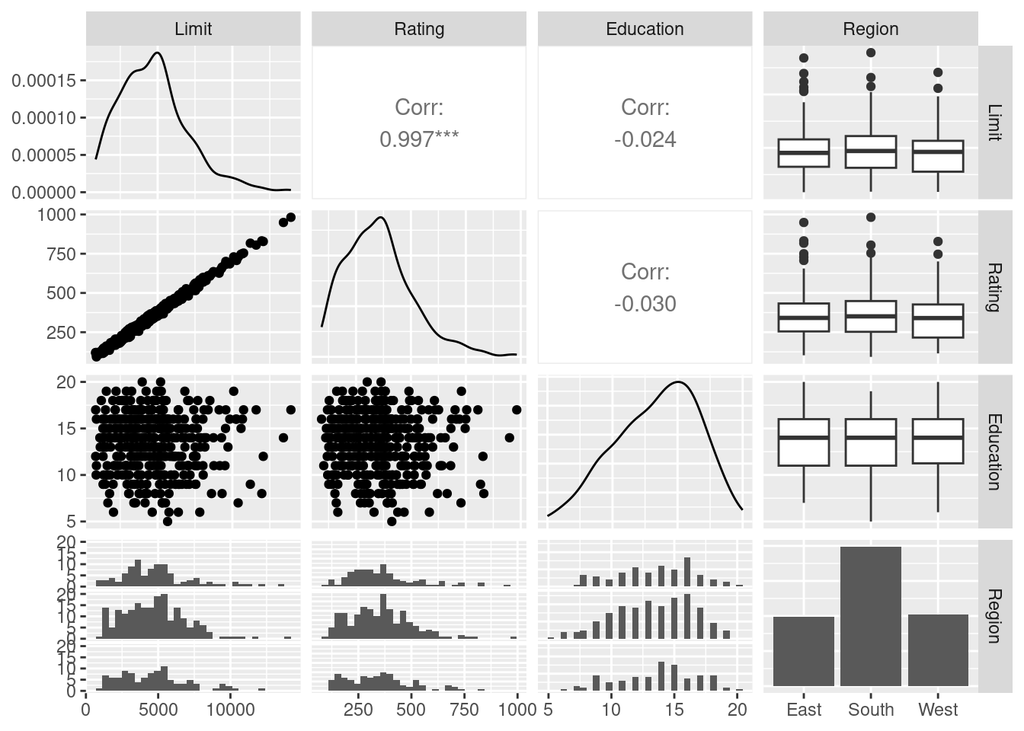

```r
Credit |>
  select(Limit, Rating, Education, Region) |>
  ggpairs()
```

## Exercise 2

Fit a linear model with just `Rating` as the predictor and get the p-value associated with it’s coefficient. Is it statistically significant?

```r
credit_fit <- lm(Limit ~ Rating, data = Credit)
tidy(credit_fit) |>
  kable(digits = 5)
```

| term | estimate | std.error | statistic | p.value |
| --- | --- | --- | --- | --- |
| (Intercept) | -542.92823 | 22.85026 | -23.76027 | 0 |
| Rating | 14.87161 | 0.05903 | 251.94906 | 0 |

Yes! it means there is high evidence that there is a relationship between Limit and Rating.

## Exercise 3

Fit a linear model with just your second quantitative predictor and get the p-value associated with it’s coefficient. Is it statistically significant?

```r
credit_fit <- lm(Limit ~ Education, data = Credit)
tidy(credit_fit) |> kable(digits = 5)
```

| term | estimate | std.error | statistic | p.value |
| --- | --- | --- | --- | --- |
| (Intercept) | 4969.52715 | 511.02858 | 9.72456 | 0.00000 |
| Education | -17.39235 | 37.01114 | -0.46992 | 0.63867 |

No. It is because our p values is greater than 0.05 which shows high evidence to null hypothesis.

## Exercise 4

Fit a model with both `Income` and your second quantitative variable as predictors. Find a spot on the white board to write down an equation representing the fitted model. How do the coefficients and p-values of `Income` and `Rating` compare to those in the two models above? Discuss what you see and the possible reasons you see them.

```r
credit_fit <- lm(Limit ~ Education + Rating, data = Credit)
tidy(credit_fit) |> kable(digits = 5)
```

| term | estimate | std.error | statistic | p.value |
| --- | --- | --- | --- | --- |
| (Intercept) | -608.52487 | 45.92867 | -13.24935 | 0.0000 |
| Education | 4.79997 | 2.91738 | 1.64530 | 0.1007 |
| Rating | 14.87453 | 0.05893 | 252.42370 | 0.0000 |

P value for education became much more significant. Also the slope of rating is high highlighting how important of a factor is credit card rating in measuring credit card limit.

## Exercise 5

Interpret all coefficients in the model.

## Exercise 6

Use `head` to look at the first observation in the data set. Use addition, subtraction, multiplication, and division to figure out what credit limit your model would predict for a person with the same characteristics of this person.

```r
head(Credit, n=1) |> kable()
```

| Income | Limit | Rating | Cards | Age | Education | Own | Student | Married | Region | Balance |
| --- | --- | --- | --- | --- | --- | --- | --- | --- | --- | --- |
| 14.891 | 3606 | 283 | 2 | 34 | 11 | No | No | Yes | South | 333 |

```r
credit_limit <- -608.52 + 4.79*11  + 14.87*283

# 3652.38
```

## Exercise 7

Now use the `predict` function to verify the value you computed in the previous exercise and compute a 90% prediction interval. How would you interpret this interval in context?

```r
predict_data <- tibble(Rating = 283, Education = 11)
predict(credit_fit, predict_data, interval = "prediction", level = 0.90)
```

```
       fit      lwr      upr
1 3653.766 3352.946 3954.587
```

90% of the times, the credit_fit falls between lower and upper level as shown.

```r
new_borrow <- head(Credit, n=10)
predict(credit_fit, new_borrow, interval = "prediction", level = 0.9)
```

```
        fit      lwr      upr
1  3653.766 3352.946 3954.587
2  6647.872 6347.013 6948.731
3  7089.783 6788.673 7390.892
4  9573.829 9271.471 9876.186
5  4778.481 4477.731 5079.232
6  7903.082 7601.441 8204.723
7  3301.578 3000.846 3602.310
8  7050.434 6748.819 7352.048
9  3410.499 3109.866 3711.133
10 6786.068 6484.060 7088.076
```

## Exercise 8

Fit a linear model predicting `Limit` from **ONLY** your categorical variable. What is the reference level?

```r
region_fit <- lm(Limit~ Region, data = Credit)
tidy(region_fit) |> kable()
```

| term | estimate | std.error | statistic | p.value |
| --- | --- | --- | --- | --- |
| (Intercept) | 4881.5960 | 232.3591 | 21.0088393 | 0.0000000 |
| RegionSouth | -153.1336 | 284.3422 | -0.5385540 | 0.5904965 |
| RegionWest | -273.7724 | 326.1803 | -0.8393286 | 0.4017901 |

## Exercise 9

WITHOUT WRITING ANY CODE except for addition, subtraction, multiplication, and addition, what would the model predict the average `Limit` to be for each of the level of your categorical variable?

```r
4881.5960
```

```
[1] 4881.596
```

```r
4881.5960 - 153.1336 #south
```

```
[1] 4728.462
```

```r
4881.5960 - 273.7724 #west
```

```
[1] 4607.824
```

## Exercise 10

Compute the average `Limit` for each level in your categorical variable. Hint: you can use “formulas” (i.e. `repsonse ~ explanatory`) in the `mean` function from the `mosaic` package. How do these answers compare to your answers from Exercise 9?

```r
mean(Limit ~ Region, data = Credit)
```

```
    East    South     West
4881.596 4728.462 4607.824
```

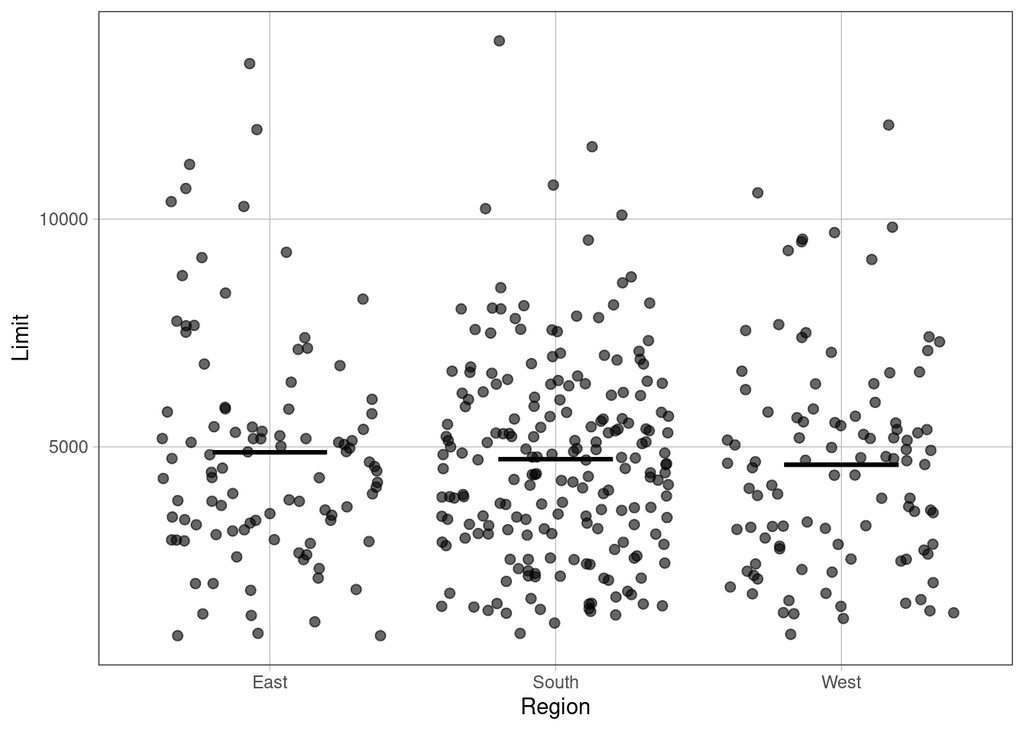

```r
library(coursekata)
gf_jitter(Limit ~ Region, data = Credit) |>
  gf_model(region_fit)
```

## Exercise 11

Fit a linear model using your quantitative and your categorical variable as predictors (don’t use `Rating`). Use the function `plotModel` to make a nifty plot for your model. Your syntax should look like `plotModel(model_name)`.

```r
original_fit <- lm(Limit ~ Education + Region, data = Credit)
tidy(original_fit) |> kable(digits = 5)
```

| term | estimate | std.error | statistic | p.value |
| --- | --- | --- | --- | --- |
| (Intercept) | 5114.40219 | 553.06733 | 9.24734 | 0.00000 |
| Education | -17.21271 | 37.09968 | -0.46396 | 0.64293 |
| RegionSouth | -156.46593 | 284.71428 | -0.54955 | 0.58293 |
| RegionWest | -272.35082 | 326.51752 | -0.83411 | 0.40472 |

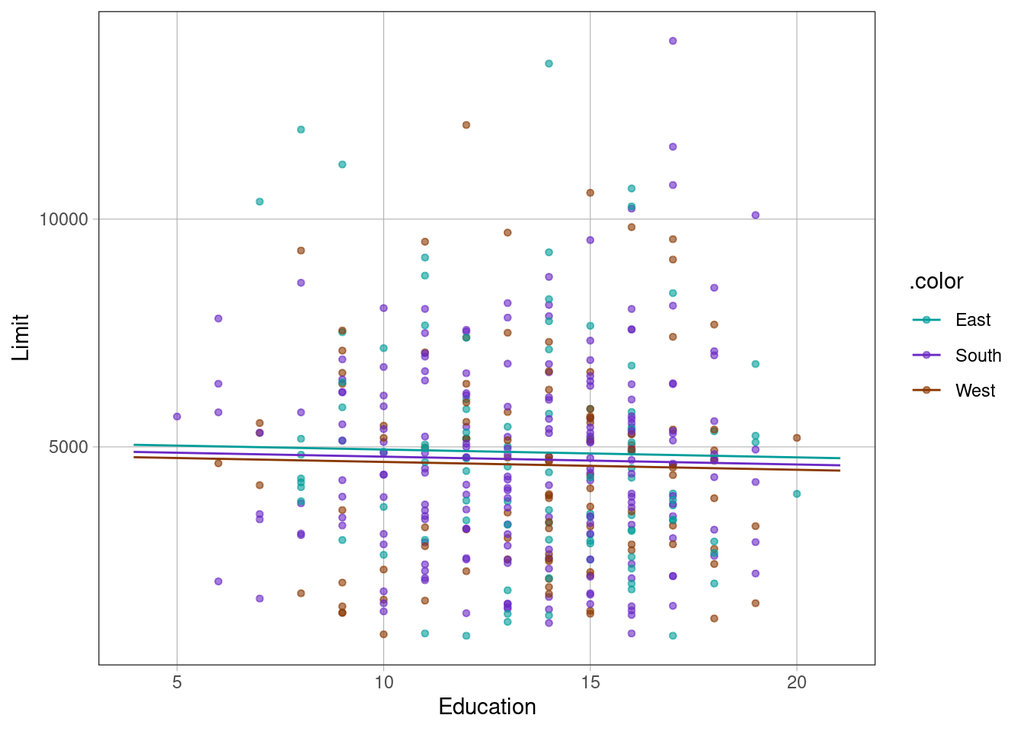

```r
plotModel(original_fit)
```

## Exercise 12

Your model contains one line for every level of your categorical variable. On the board, write out the equations for two of them.

Done

## Exercise 13

How do you think the plot above will change if you add in an interaction term between your variables? **AFTER** thinking about it, add in an in the interaction term and plot the model using `plotModel`.

```r
interaction_fit <- lm(Limit ~ Education + Region + (Education * Region), data = Credit)
tidy(interaction_fit) |> kable(digits = 5)
```

| term | estimate | std.error | statistic | p.value |
| --- | --- | --- | --- | --- |
| (Intercept) | 7159.8361 | 1046.17983 | 6.84379 | 0.00000 |
| Education | -168.4435 | 75.43211 | -2.23305 | 0.02611 |
| RegionSouth | -3078.4760 | 1268.00417 | -2.42781 | 0.01564 |
| RegionWest | -2499.3976 | 1452.47032 | -1.72079 | 0.08607 |
| Education:RegionSouth | 216.9822 | 91.80541 | 2.36350 | 0.01859 |
| Education:RegionWest | 164.5769 | 104.36156 | 1.57699 | 0.11560 |

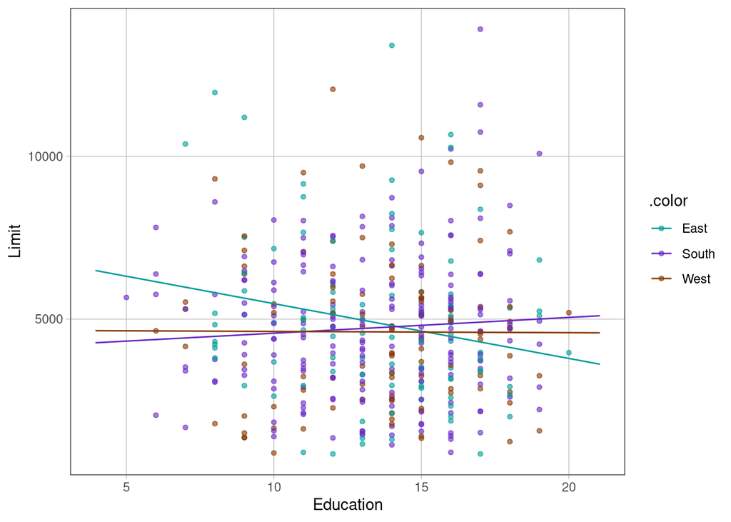

```r
plotModel(interaction_fit)
```

## Exercise 14

Your model contains one line for every level of your categorical variable. On the board, write out the equations for two of them.

LIMIT for East = (7159.8) - 168.4 * Education

LIMIT for South= (7159.8-3078.4) +(-168.4435+216.98) * Education

LIMIT for West = (7159.8 - 2499.4) + (-168.4435+164.58) * Education

## Exercise 15

Fit a model with your quantitative predictor, `Rating`, and an interaction term. Write your model on the board.

```r
interaction_fitr <- lm(Limit ~ Rating + Education + (Rating * Education), data = Credit)
tidy(interaction_fitr) |> kable(digits = 5)
```

| term | estimate | std.error | statistic | p.value |
| --- | --- | --- | --- | --- |
| (Intercept) | -617.71545 | 104.65994 | -5.90212 | 0.00000 |
| Rating | 14.89948 | 0.26199 | 56.87095 | 0.00000 |
| Education | 5.47611 | 7.50815 | 0.72936 | 0.46622 |
| Rating:Education | -0.00184 | 0.01883 | -0.09776 | 0.92218 |

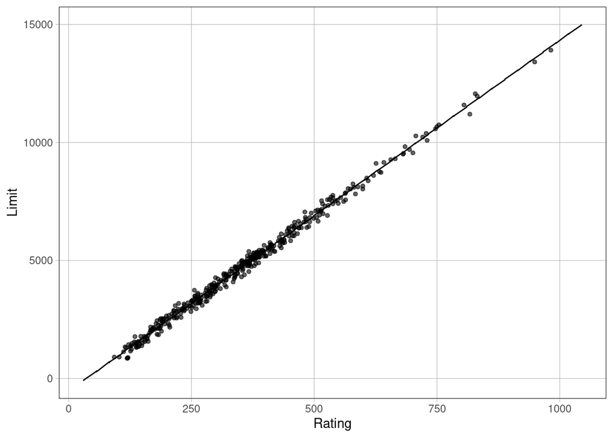

```r
plotModel(interaction_fitr)
```

## Exercise 16 (Optional)

Look back at all of the models that you’ve fit. If you compare the p-values for the same variable across multiple models, what do you notice?

## Exercise 17 (Optional)

Note that this data set only considers borrowers who have actually been granted loans. How does this impact the generalizability of our analysis?

## To submit the AE

**Important**

- Render the document to produce the HTML file with all of your work from today’s class.
- Upload your QMD and HTML files to the Canvas assignment.